# MSc ENR ISM: Biodiversity analysis (alpha, beta, gamma)

Author

Marius King

Published

April 26, 2025

Abstract

Analysis of the alpha, beta and gamma diversity of wetlands in the Gantrisch region (Switzerland) using R v4.5.0 (R Core Team 2025) and vegan (Oksanen et al. 2025).

### *setup*

```r
pacman::p_load("tidyverse", "vegan", "patchwork", "ggpubr", "knitr")

set.seed(123)

theme_set(
  theme_minimal()+
  theme(
    strip.background = element_rect(fill = "black"),
    strip.text = element_text(color = "white"),
    panel.spacing = unit(0.5, "lines"),
    axis.text = element_text(color = gray(0.3)),
    panel.border = element_rect(color = "black",fill=NA)
  )
)

colors <- c(
  "grazing"="#6B8E23",
  "mowing"="#A8D08D"
)
```

## 1 Structure of community ecology data

**(a)** Import the community ecology data (vegetation data) from the file “Wet_Grasland.xlsx”. Tip: Remember that community ecology data consists of species data and header/environmental data. Consider to set the first column (Taxa names resp. Plot names) as rownames

**(b)** Check the data. How is the data structured? Are there NAs?

**(c)** Often in species data, as a convention and for better readability, cells are left empty if a species is not present at a sampling unit (here plot). But for analysis there should be a 0 if a species is not in the plot ► change the NAs to 0 in the Species data.

```r
wet_grasland <- read_delim("data/wet_grasland.csv")

wet_grasland |> str()
```

```
spc_tbl_ [110 × 37] (S3: spec_tbl_df/tbl_df/tbl/data.frame)
 $ Species: chr [1:110] "Acer pseudoplatanus L." "Achillea millefolium L." "Aconitum napellus L." "Ajuga reptans L." ...
 $ P111   : num [1:110] NA NA NA NA NA 2 1 15 NA NA ...
 $ P112   : num [1:110] NA NA NA NA NA 0.1 NA 8 NA NA ...
 $ P121   : num [1:110] NA NA NA NA NA NA 15 20 NA NA ...
 $ P122   : num [1:110] NA NA NA NA NA 2 3 10 NA 0.5 ...
 $ P131   : num [1:110] NA NA NA 1 NA 0.3 NA 15 NA NA ...
 $ P132   : num [1:110] NA NA NA 2 NA 2 NA 1.5 NA NA ...
 $ P211   : num [1:110] NA NA NA 8 NA 0.5 NA 10 NA NA ...
 $ P212   : num [1:110] NA NA NA 0.6 NA 0.5 NA 1 NA NA ...
 $ P221   : num [1:110] NA NA NA 8 NA NA NA 0.5 NA NA ...
 $ P222   : num [1:110] NA NA NA 3 NA NA NA 6 NA NA ...
 $ P231   : num [1:110] NA NA NA 1 NA 1 NA 10 NA NA ...
 $ P232   : num [1:110] 0.05 NA NA NA NA NA NA 0.1 NA NA ...
 $ P311   : num [1:110] NA NA NA 1 NA 1 NA 8 NA NA ...
 $ P312   : num [1:110] NA NA NA 3 NA 0.3 NA 8 NA NA ...
 $ P321   : num [1:110] NA NA NA 5 NA 1 NA 8 NA NA ...
 $ P322   : num [1:110] NA 0.05 NA 10 NA NA NA 2 0.01 NA ...
 $ P331   : num [1:110] NA NA NA 8 NA NA NA 3 NA NA ...
 $ P332   : num [1:110] NA NA NA 2 NA NA NA 2 NA NA ...
 $ P411   : num [1:110] NA NA NA NA NA NA NA 8 NA 0.2 ...
 $ P412   : num [1:110] NA NA NA NA NA 1 NA 8 NA NA ...
 $ P421   : num [1:110] NA NA NA NA NA NA NA 6 NA NA ...
 $ P422   : num [1:110] NA NA NA NA NA 0.3 0.1 8 NA NA ...
 $ P431   : num [1:110] NA NA NA 1 NA 10 NA 3 NA NA ...
 $ P432   : num [1:110] NA NA NA 2 NA 5 1 5 NA NA ...
 $ P511   : num [1:110] NA NA NA NA NA 0.3 NA 3 NA NA ...
 $ P512   : num [1:110] NA NA NA NA NA NA NA 0.8 NA NA ...
 $ P521   : num [1:110] NA NA NA 0.7 NA NA NA 0.2 NA NA ...
 $ P522   : num [1:110] NA NA NA 15 NA NA NA 0.8 NA NA ...
 $ P531   : num [1:110] NA NA NA 2 NA NA 0.3 5 NA NA ...
 $ P532   : num [1:110] NA NA NA 1 NA NA 25 NA NA NA ...
 $ P611   : num [1:110] NA NA NA 5 NA NA NA NA NA NA ...
 $ P612   : num [1:110] NA NA NA 1 0.8 0.5 NA 7 NA NA ...
 $ P621   : num [1:110] NA NA 1 5 NA NA NA 0.2 NA NA ...
 $ P622   : num [1:110] NA NA NA 1 NA NA NA 1 NA NA ...
 $ P631   : num [1:110] NA NA NA 8 NA 0.3 NA 15 NA NA ...
 $ P632   : num [1:110] NA NA NA 3 NA NA NA 15 NA NA ...
 - attr(*, "spec")=
  .. cols(
```

[output cut: 24 more lines]

```
  ..   P432 = col_double(),
  ..   P511 = col_double(),
  ..   P512 = col_double(),
  ..   P521 = col_double(),
  ..   P522 = col_double(),
  ..   P531 = col_double(),
  ..   P532 = col_double(),
  ..   P611 = col_double(),
  ..   P612 = col_double(),
  ..   P621 = col_double(),
  ..   P622 = col_double(),
  ..   P631 = col_double(),
  ..   P632 = col_double()
  .. )
 - attr(*, "problems")=<externalptr>
```

```r
wet_grasland |> summary()
```

```
   Species               P111             P112             P121
 Length:110         Min.   : 0.100   Min.   : 0.001   Min.   : 0.500
 Class :character   1st Qu.: 1.250   1st Qu.: 0.500   1st Qu.: 1.250
 Mode  :character   Median : 5.000   Median : 3.000   Median : 5.500
                    Mean   : 6.768   Mean   : 7.507   Mean   : 6.386
                    3rd Qu.:10.000   3rd Qu.: 8.000   3rd Qu.: 8.000
                    Max.   :20.000   Max.   :60.000   Max.   :20.000
                    NA's   :88       NA's   :83       NA's   :88
      P122             P131             P132             P211
 Min.   : 0.010   Min.   : 0.001   Min.   : 0.010   Min.   : 0.001
 1st Qu.: 0.150   1st Qu.: 0.200   1st Qu.: 0.500   1st Qu.: 0.500
 Median : 0.500   Median : 2.000   Median : 1.000   Median : 1.000
 Mean   : 4.712   Mean   : 4.479   Mean   : 3.864   Mean   : 4.508
 3rd Qu.: 3.000   3rd Qu.: 6.000   3rd Qu.: 4.250   3rd Qu.: 8.000
 Max.   :30.000   Max.   :35.000   Max.   :25.000   Max.   :30.000
 NA's   :75       NA's   :79       NA's   :74       NA's   :75
      P212             P221             P222            P231
 Min.   : 0.001   Min.   : 0.010   Min.   : 0.05   Min.   : 0.010
 1st Qu.: 0.250   1st Qu.: 0.500   1st Qu.: 1.00   1st Qu.: 0.300
 Median : 1.000   Median : 1.250   Median : 4.00   Median : 1.000
 Mean   : 3.983   Mean   : 5.728   Mean   : 7.51   Mean   : 4.352
 3rd Qu.: 6.500   3rd Qu.: 8.500   3rd Qu.: 8.00   3rd Qu.: 5.000
 Max.   :30.000   Max.   :35.000   Max.   :40.00   Max.   :20.000
 NA's   :71       NA's   :82       NA's   :89      NA's   :81
      P232             P311             P312             P321
 Min.   : 0.001   Min.   : 0.010   Min.   : 0.001   Min.   : 0.001
 1st Qu.: 0.100   1st Qu.: 0.500   1st Qu.: 0.100   1st Qu.: 0.500
 Median : 0.300   Median : 1.250   Median : 1.000   Median : 2.000
 Mean   : 3.997   Mean   : 4.573   Mean   : 4.062   Mean   : 4.675
 3rd Qu.: 8.000   3rd Qu.: 5.750   3rd Qu.: 5.000   3rd Qu.: 5.000
 Max.   :20.000   Max.   :25.000   Max.   :18.000   Max.   :30.000
 NA's   :81       NA's   :72       NA's   :77       NA's   :69
      P322              P331             P332             P411
 Min.   : 0.0010   Min.   : 0.010   Min.   : 0.100   Min.   : 0.050
 1st Qu.: 0.0875   1st Qu.: 0.200   1st Qu.: 0.900   1st Qu.: 0.500
 Median : 0.8000   Median : 2.000   Median : 2.000   Median : 1.000
 Mean   : 4.7873   Mean   : 5.245   Mean   : 7.463   Mean   : 5.155
 3rd Qu.: 6.2500   3rd Qu.: 7.250   3rd Qu.:10.000   3rd Qu.: 8.000
 Max.   :30.0000   Max.   :25.000   Max.   :35.000   Max.   :30.000
 NA's   :74        NA's   :84       NA's   :91       NA's   :82
```

[output cut: 25 more lines]

```
 Min.   : 0.010   Min.   : 0.050   Min.   : 0.010   Min.   : 0.010
 1st Qu.: 0.300   1st Qu.: 0.300   1st Qu.: 0.275   1st Qu.: 0.275
 Median : 1.000   Median : 1.000   Median : 1.250   Median : 0.900
 Mean   : 4.167   Mean   : 5.507   Mean   : 5.774   Mean   : 4.492
 3rd Qu.: 5.250   3rd Qu.: 7.000   3rd Qu.: 5.000   3rd Qu.: 8.000
 Max.   :30.000   Max.   :40.000   Max.   :40.000   Max.   :25.000
 NA's   :70       NA's   :74       NA's   :80       NA's   :70
      P632
 Min.   : 0.001
 1st Qu.: 0.450
 Median : 2.000
 Mean   : 6.197
 3rd Qu.:10.000
 Max.   :30.000
 NA's   :75
```

```r
wet_grasland <- wet_grasland |>
  mutate(
    Species = factor(Species),
    across(everything(), ~replace_na(., 0))
  )
```

```r
wet_grasland_header <- read_delim("data/wet_grasland_head.csv")

wet_grasland_header |> str()
```

```
spc_tbl_ [36 × 34] (S3: spec_tbl_df/tbl_df/tbl/data.frame)
 $ Plot                  : chr [1:36] "P111" "P112" "P121" "P122" ...
 $ Mire_Pair             : chr [1:36] "1_1" "1_2" "1_3" "2_1" ...
 $ Plot_size_m2          : num [1:36] 10 10 10 10 10 10 10 10 10 10 ...
 $ Date                  : chr [1:36] "12/06/2021" "13/06/2021" "13/06/2021" "11/06/2021" ...
 $ Management            : chr [1:36] "grazing" "grazing" "grazing" "grazing" ...
 $ Municipality          : chr [1:36] "Guggisberg" "Guggisberg" "Guggisberg" "Rueschegg" ...
 $ X_coordinate          : num [1:36] 7.36 7.36 7.36 7.38 7.38 ...
 $ Y_coordinate          : num [1:36] 46.8 46.8 46.8 46.7 46.8 ...
 $ Elevation             : num [1:36] 1160 1167 1167 1325 1303 ...
 $ Aspect                : num [1:36] 270 285 310 335 335 35 20 335 345 110 ...
 $ southing              : num [1:36] 0 -0.259 -0.643 -0.906 -0.906 ...
 $ easting               : num [1:36] 1 0.966 0.766 0.423 0.423 ...
 $ Inclination           : num [1:36] 18 17 4 15 8 13 5 0 12 14 ...
 $ Max_Microrelief       : num [1:36] 21 15 14 23 14 15 19 13 18 28 ...
 $ Soil_depth_1          : num [1:36] 37 61 42 67 68 44 60 77 67 70 ...
 $ Soil_depth_2          : num [1:36] 52 62 49 51 68 51 61 76 62 82 ...
 $ Soil_depth_3          : num [1:36] 47 60 56 62 40 50 55 67 28 44 ...
 $ Soil_depth_4          : num [1:36] 42 59 38 59 58 66 49 51 71 82 ...
 $ Soil_depth_5          : num [1:36] 38 65 65 56 61 46 41 72 57 71 ...
 $ Soil_depth_mean       : num [1:36] 43.2 61.4 50 59 59 51.4 53.2 68.6 57 69.8 ...
 $ Soil_depth_SD         : num [1:36] 6.3 2.3 10.84 6.04 11.49 ...
 $ Max_Vegetation_height : num [1:36] 75 81 90 67 57 55 74 120 78 80 ...
 $ Vegetation_height_1   : num [1:36] 48 26 42 17 35 11 23 20 22 27 ...
 $ Vegetation_height_2   : num [1:36] 27 48 39 11 22 9 9 33 30 43 ...
 $ Vegetation_height_3   : num [1:36] 6 18 8 12 20 27 20 28 24 49 ...
 $ Vegetation_height_4   : num [1:36] 3 19 24 18 13 12 12 39 27 27 ...
 $ Vegetation_height_5   : num [1:36] 24 25 10 10 15 11 14 22 25 28 ...
 $ Vegetation_height_mean: num [1:36] 21.6 27.2 24.6 13.6 21 14 15.6 28.4 25.6 34.8 ...
 $ Vegetation_height_SD  : num [1:36] 18.17 12.15 15.81 3.65 8.63 ...
 $ Cover_vegetation      : num [1:36] 70 90 70 87 90 85 80 85 90 85 ...
 $ Cover_herbaceous      : num [1:36] 65 75 68 65 75 65 80 80 80 75 ...
 $ Cover_moss            : num [1:36] 30 45 3 50 50 55 1 20 55 45 ...
 $ Cover_litter          : num [1:36] 5 10 8 8 12 15 25 35 15 8 ...
 $ pH                    : num [1:36] 6.44 6.88 6.61 6.59 6.7 6.57 6.35 6.4 6.93 5.54 ...
 - attr(*, "spec")=
  .. cols(
  ..   Plot = col_character(),
  ..   Mire_Pair = col_character(),
  ..   Plot_size_m2 = col_double(),
```

[output cut: 18 more lines]

```
  ..   Max_Vegetation_height = col_double(),
  ..   Vegetation_height_1 = col_double(),
  ..   Vegetation_height_2 = col_double(),
  ..   Vegetation_height_3 = col_double(),
  ..   Vegetation_height_4 = col_double(),
  ..   Vegetation_height_5 = col_double(),
  ..   Vegetation_height_mean = col_double(),
  ..   Vegetation_height_SD = col_double(),
  ..   Cover_vegetation = col_double(),
  ..   Cover_herbaceous = col_double(),
  ..   Cover_moss = col_double(),
  ..   Cover_litter = col_double(),
  ..   pH = col_double()
  .. )
 - attr(*, "problems")=<externalptr>
```

```r
wet_grasland_header |> summary()
```

```
     Plot            Mire_Pair          Plot_size_m2     Date
 Length:36          Length:36          Min.   :10    Length:36
 Class :character   Class :character   1st Qu.:10    Class :character
 Mode  :character   Mode  :character   Median :10    Mode  :character
                                       Mean   :10
                                       3rd Qu.:10
                                       Max.   :10
  Management        Municipality        X_coordinate    Y_coordinate
 Length:36          Length:36          Min.   :7.355   Min.   :46.75
 Class :character   Class :character   1st Qu.:7.378   1st Qu.:46.75
 Mode  :character   Mode  :character   Median :7.410   Median :46.75
                                       Mean   :7.405   Mean   :46.75
                                       3rd Qu.:7.436   3rd Qu.:46.76
                                       Max.   :7.443   Max.   :46.76
   Elevation        Aspect         southing          easting
 Min.   :1138   Min.   :  0.0   Min.   :-1.0000   Min.   :-0.9397
 1st Qu.:1166   1st Qu.: 35.0   1st Qu.:-0.9397   1st Qu.:-0.3420
 Median :1203   Median :292.5   Median :-0.8660   Median : 0.3420
 Mean   :1210   Mean   :223.1   Mean   :-0.6839   Mean   : 0.2390
 3rd Qu.:1239   3rd Qu.:335.0   3rd Qu.:-0.6071   3rd Qu.: 0.7660
 Max.   :1325   Max.   :350.0   Max.   : 0.3420   Max.   : 1.0000
  Inclination     Max_Microrelief  Soil_depth_1    Soil_depth_2
 Min.   : 0.000   Min.   : 2.00   Min.   :12.00   Min.   :19.00
 1st Qu.: 5.750   1st Qu.: 7.00   1st Qu.:43.50   1st Qu.:49.75
 Median : 9.000   Median :12.50   Median :59.00   Median :61.50
 Mean   : 9.639   Mean   :12.14   Mean   :55.53   Mean   :59.22
 3rd Qu.:13.250   3rd Qu.:15.25   3rd Qu.:69.00   3rd Qu.:75.25
 Max.   :25.000   Max.   :28.00   Max.   :82.00   Max.   :82.00
  Soil_depth_3    Soil_depth_4    Soil_depth_5   Soil_depth_mean
 Min.   :16.00   Min.   :13.00   Min.   :17.00   Min.   :26.80
 1st Qu.:42.00   1st Qu.:44.75   1st Qu.:41.00   1st Qu.:44.40
 Median :54.50   Median :50.00   Median :59.50   Median :57.40
 Mean   :53.50   Mean   :53.25   Mean   :55.53   Mean   :55.41
 3rd Qu.:64.25   3rd Qu.:64.50   3rd Qu.:66.00   3rd Qu.:62.80
 Max.   :82.00   Max.   :82.00   Max.   :82.00   Max.   :82.00
 Soil_depth_SD   Max_Vegetation_height Vegetation_height_1 Vegetation_height_2
 Min.   : 0.00   Min.   : 50.00        Min.   : 4.00       Min.   : 8.00
 1st Qu.: 8.18   1st Qu.: 69.25        1st Qu.:12.88       1st Qu.:13.75
 Median :11.86   Median : 76.50        Median :18.00       Median :19.00
 Mean   :12.09   Mean   : 78.97        Mean   :22.76       Mean   :21.03
```

[output cut: 8 more lines]

```
 Max.   :49.00       Max.   :49.00       Max.   :53.00
 Vegetation_height_mean Vegetation_height_SD Cover_vegetation Cover_herbaceous
 Min.   : 9.60          Min.   : 1.670       Min.   :70.00    Min.   :65.00
 1st Qu.:14.68          1st Qu.: 3.578       1st Qu.:85.00    1st Qu.:75.00
 Median :18.30          Median : 5.980       Median :90.00    Median :80.00
 Mean   :20.49          Mean   : 7.286       Mean   :88.42    Mean   :78.69
 3rd Qu.:25.80          3rd Qu.: 8.777       3rd Qu.:95.00    3rd Qu.:85.00
 Max.   :35.80          Max.   :18.170       Max.   :99.00    Max.   :95.00
   Cover_moss     Cover_litter         pH
 Min.   : 1.00   Min.   : 1.00   Min.   :4.730
 1st Qu.:37.50   1st Qu.: 8.00   1st Qu.:6.180
 Median :52.50   Median :10.00   Median :6.580
 Mean   :47.92   Mean   :16.03   Mean   :6.402
 3rd Qu.:65.00   3rd Qu.:16.25   3rd Qu.:6.728
 Max.   :80.00   Max.   :55.00   Max.   :7.240
```

```r
wet_grasland_header <- wet_grasland_header|>
  mutate(
    Plot = factor(Plot),
    Mire_Pair = factor(Mire_Pair),
    Management = factor(Management),
    Municipality = factor(Municipality),
    Date = as.POSIXct(Date, format="%d/%m/%Y")
  )
```

## 2 Community diversity

**(a)** For most operations/calculations on the species data we need the sampling units (here plots) as rows and the species as columns ► transpose the species data data frame.

**(b)** Calculate species richness. Hint: Use a base R function or the `specnumber` function of the package `vegan`

**(c)** Use the function `diversity` of the package `vegan` to calculate the Shannon diversity and the Shannon eveness

**(d)** Add the diversity measures calculated in (b) and (c) to the Header/Environmental Data

```r
wet_grasland_alpha <- wet_grasland |>
  pivot_longer(-Species, names_to = "Plot", values_to = "Abundance") |>
  group_by(Plot) |>
  summarise(
    shannon = diversity(Abundance),
    simpson = diversity(Abundance, index="simpson"),
    species_richness = specnumber(Abundance),
    eveness = shannon/log(species_richness)
  )

wet_grasland_alpha |> str()
```

```
tibble [36 × 5] (S3: tbl_df/tbl/data.frame)
 $ Plot            : chr [1:36] "P111" "P112" "P121" "P122" ...
 $ shannon         : num [1:36] 2.68 2.36 2.69 2.43 2.52 ...
 $ simpson         : num [1:36] 0.917 0.851 0.917 0.882 0.884 ...
 $ species_richness: int [1:36] 22 27 22 35 31 36 35 39 28 21 ...
 $ eveness         : num [1:36] 0.866 0.715 0.871 0.684 0.733 ...
```

```r
wet_grasland_header <- left_join(
  wet_grasland_header,
  wet_grasland_alpha,
  join_by(Plot)
)
```

```r
aov(species_richness~Management, wet_grasland_header) |> summary()
```

```
            Df Sum Sq Mean Sq F value Pr(>F)
Management   1    0.1    0.11   0.003  0.958
Residuals   34 1339.9   39.41
```

```r
aov(eveness~Management, wet_grasland_header) |> summary()
```

```
            Df  Sum Sq  Mean Sq F value Pr(>F)
Management   1 0.00194 0.001938   0.737  0.397
Residuals   34 0.08945 0.002631
```

```r
aov(shannon~Management, wet_grasland_header) |> summary()
```

```
            Df Sum Sq Mean Sq F value Pr(>F)
Management   1 0.0164 0.01641   0.279  0.601
Residuals   34 2.0031 0.05891
```

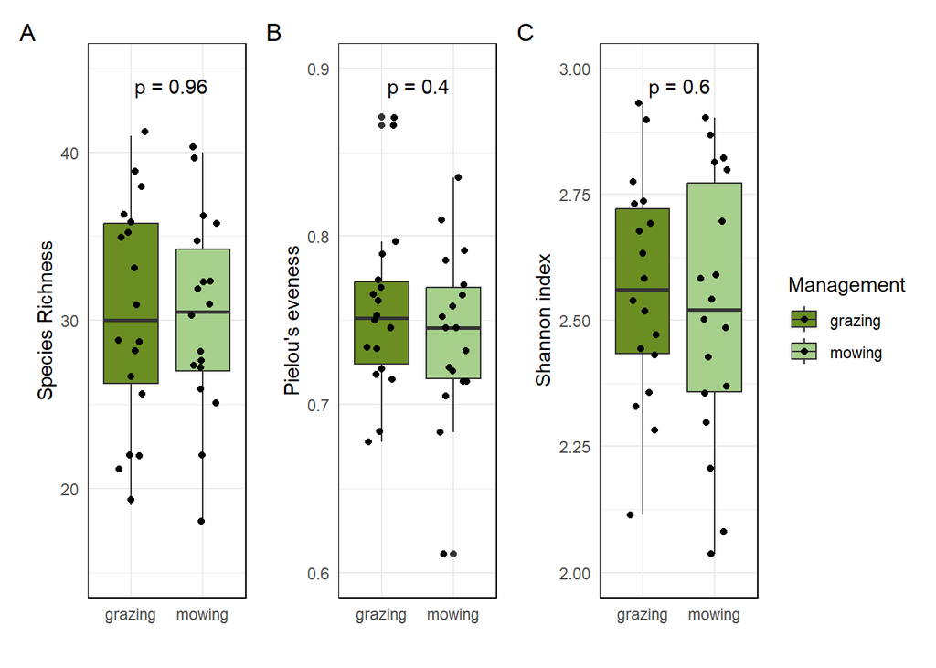

```r
plot_specnumber <- wet_grasland_header |>
  ggplot(aes(Management, species_richness, fill=Management)) +
  geom_boxplot()+
  geom_jitter(width=0.2)+
  stat_compare_means(
    method = "anova",
    label = "p.format",
    label.x = 1.25,
    label.y = 15+30*0.95
  )+
  scale_y_continuous(
    limits=c(15,45)
  )+
  scale_fill_manual(
    values=colors
  )+
  labs(
    x="",
    y="Species Richness"
  )+
  theme(legend.position = "none")

plot_eveness <- wet_grasland_header |>
  ggplot(aes(Management, eveness, fill=Management)) +
  geom_boxplot()+
  geom_jitter(width=0.2)+
  stat_compare_means(
    method = "anova",
    label = "p.format",
    label.x = 1.25,
    label.y = 0.6+0.3*0.95
  )+
  scale_y_continuous(
    limits=c(0.6,0.9)
  )+
  scale_fill_manual(
    values=colors
  )+
  labs(
    x="",
    y="Pielou's eveness"
  )+
  theme(legend.position = "none")

plot_shannon <- wet_grasland_header |>
  ggplot(aes(Management, shannon, fill=Management)) +
  geom_boxplot()+
  geom_jitter(width=0.2)+
  stat_compare_means(
    method = "anova",
    label = "p.format",
    label.x = 1.25,
    label.y = 2+1*0.95
  )+
  scale_y_continuous(
    limits=c(2,3)
  )+
  scale_fill_manual(
    values=colors
  )+
  labs(
    x="",
    y="Shannon index"
  )

plot_alpha <- plot_specnumber +
  plot_eveness +
  plot_shannon+
  plot_annotation(tag_levels = "A")

plot_alpha
```

```r
ggsave(
  "plot_alpha.jpg",
  plot=plot_alpha,
  width=24,
  height=12,
  units = "cm"
)
```

**(e)** Calculate the observed gamma diversity separatly for both managements types (grazed, mowed)

**(f)** Calculate the mean beta diversity separately for both management types (grazed, mowed)

**(g)** Calculate the (plot-wise) beta diversity separately for both managements types (grazed, mowed)

```r
wet_grasland_gamma <- wet_grasland |>
  pivot_longer(-Species, names_to = "Plot", values_to = "Abundance") |>
  left_join(
    wet_grasland_header,
    join_by(Plot)
  ) |>
  group_by(Management,Species) |>
  summarise(
    present = sum(Abundance)>0,
    .groups = "drop") |>
  group_by(Management) |>
  summarise(gamma = sum(present))

wet_grasland_gamma |> str()
```

```
tibble [2 × 2] (S3: tbl_df/tbl/data.frame)
 $ Management: Factor w/ 2 levels "grazing","mowing": 1 2
 $ gamma     : int [1:2] 96 86
```

```r
wet_grasland_header <- left_join(
  wet_grasland_header,
  wet_grasland_gamma,
  join_by(Management)
)
```

```r
wet_grasland_beta <- wet_grasland_header |>
  select(
    Plot,Management,shannon,species_richness,eveness,gamma
  ) |>
  group_by(Management) |>
  mutate(
    mean_species_richness = species_richness |> mean(),
    .groups = "drop"
  ) |>
  mutate(
    beta_mean = gamma/mean_species_richness,
    beta = gamma/species_richness
  )

wet_grasland_beta |> str()
```

```
gropd_df [36 × 10] (S3: grouped_df/tbl_df/tbl/data.frame)
 $ Plot                 : chr [1:36] "P111" "P112" "P121" "P122" ...
 $ Management           : Factor w/ 2 levels "grazing","mowing": 1 1 1 1 1 1 1 1 1 1 ...
 $ shannon              : num [1:36] 2.68 2.36 2.69 2.43 2.52 ...
 $ species_richness     : int [1:36] 22 27 22 35 31 36 35 39 28 21 ...
 $ eveness              : num [1:36] 0.866 0.715 0.871 0.684 0.733 ...
 $ gamma                : int [1:36] 96 96 96 96 96 96 96 96 96 96 ...
 $ mean_species_richness: num [1:36] 30.4 30.4 30.4 30.4 30.4 ...
 $ .groups              : chr [1:36] "drop" "drop" "drop" "drop" ...
 $ beta_mean            : num [1:36] 3.16 3.16 3.16 3.16 3.16 ...
 $ beta                 : num [1:36] 4.36 3.56 4.36 2.74 3.1 ...
 - attr(*, "groups")= tibble [2 × 2] (S3: tbl_df/tbl/data.frame)
  ..$ Management: Factor w/ 2 levels "grazing","mowing": 1 2
  ..$ .rows     : list<int> [1:2]
  .. ..$ : int [1:18] 1 2 3 4 5 6 7 8 9 10 ...
  .. ..$ : int [1:18] 19 20 21 22 23 24 25 26 27 28 ...
  .. ..@ ptype: int(0)
  ..- attr(*, ".drop")= logi TRUE
```

```r
aov(beta~Management, wet_grasland_beta) |> summary()
```

```
            Df Sum Sq Mean Sq F value Pr(>F)
Management   1  1.216  1.2161   2.274  0.141
Residuals   34 18.181  0.5347
```

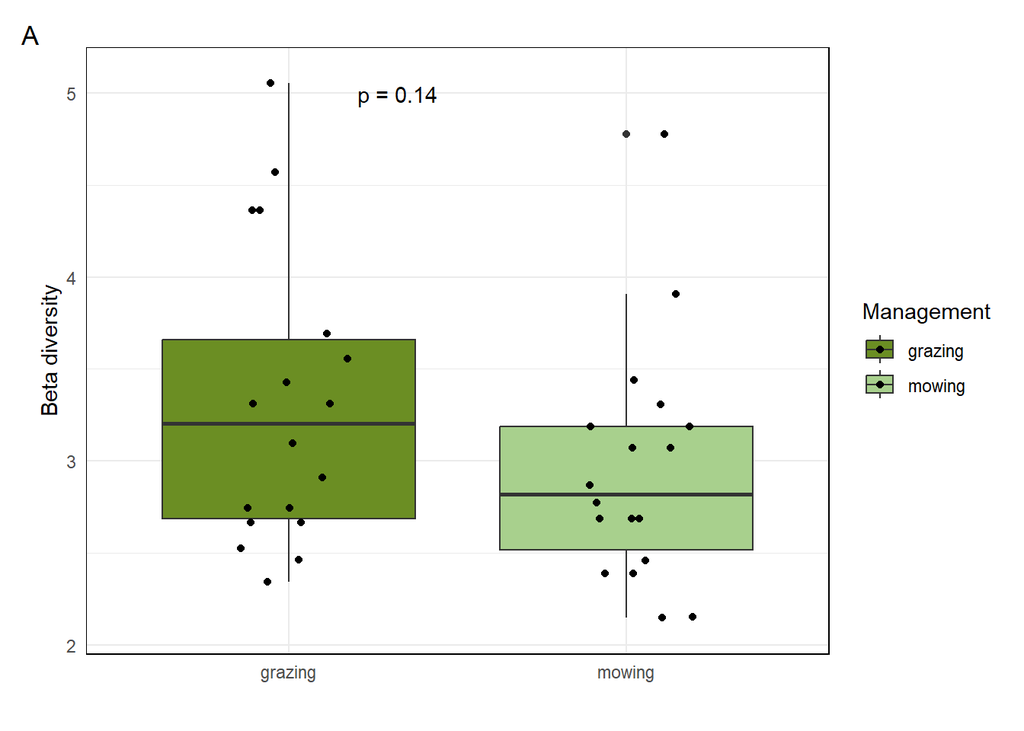

```r
plot_beta <- wet_grasland_beta |>
  ggplot(aes(Management, beta, fill=Management)) +
  geom_boxplot()+
  geom_jitter(width=0.2)+
  stat_compare_means(
    method = "anova",
    label = "p.format",
    label.x = 1.25,
    label.y = 2.1+3*0.95
  )+
  scale_y_continuous(
    limits=c(2.1,5.1)
  )+
  scale_fill_manual(
    values=colors
  )+
  labs(
    x="",
    y="Beta diversity"
  )

plot_beta +
  plot_annotation(tag_levels = "A")
```

```r
wet_grasland_beta |>
  group_by(Management) |>
  summarise(
    species_richness_min = min(species_richness),
    species_richness_mean = mean(species_richness),
    species_richness_max = max(species_richness),
    species_richness_sd = sd(species_richness),
    eveness_min = min(eveness),
    eveness_mean = mean(eveness),
    eveness_max = max(eveness),
    eveness_sd = sd(eveness),
    shannon_min = min(shannon),
    shannon_mean = mean(shannon),
    shannon_max = max(shannon),
    shannon_sd = sd(shannon),
    gamma = first(gamma),
    beta_min_plotwise=min(beta),
    beta_mean_plotwise=mean(beta),
    beta_max_plotwise=max(beta),
    beta_sd_plotwise=sd(beta),
    beta_mean = first(beta_mean)
  ) |>
  pivot_longer(
    cols = -Management,
    names_to = "metric",
    values_to = "value"
  ) |>
  pivot_wider(
    names_from = Management,
    values_from = value
  ) |>
  kable(digits = 2)
```

| metric | grazing | mowing |
| --- | --- | --- |
| species_richness_min | 19.00 | 18.00 |
| species_richness_mean | 30.39 | 30.28 |
| species_richness_max | 41.00 | 40.00 |
| species_richness_sd | 6.67 | 5.86 |
| eveness_min | 0.68 | 0.61 |
| eveness_mean | 0.76 | 0.74 |
| eveness_max | 0.87 | 0.84 |
| eveness_sd | 0.05 | 0.05 |
| shannon_min | 2.11 | 2.04 |
| shannon_mean | 2.56 | 2.52 |
| shannon_max | 2.93 | 2.90 |
| shannon_sd | 0.22 | 0.27 |
| gamma | 96.00 | 86.00 |
| beta_min_plotwise | 2.34 | 2.15 |
| beta_mean_plotwise | 3.32 | 2.95 |
| beta_max_plotwise | 5.05 | 4.78 |
| beta_sd_plotwise | 0.80 | 0.65 |
| beta_mean | 3.16 | 2.84 |

## References

Oksanen, Jari, Gavin L. Simpson, F. Guillaume Blanchet, Roeland Kindt, Pierre Legendre, Peter R. Minchin, R. B. O’Hara, et al. 2025. *Vegan: Community Ecology Package*. https://CRAN.R-project.org/package=vegan.

R Core Team. 2025. *R: A Language and Environment for Statistical Computing*. Vienna, Austria: R Foundation for Statistical Computing. https://www.R-project.org/.